# Datathon Classification

Ryuta Yoshimatsu

# 1 Load Libraries

To **install** and add new package, run `install.packages('package_name')` in **RStudio Console** and add a line `library('package_name')` below

```r
library(statsr)
library(dplyr)
library(MASS)
library(BAS)
library(ggplot2)
library(devtools)
library(gridExtra)
library(grid)
library(GGally)
library(PreProcess)
library(tidyverse)
library(knitr)
```

# 2 Load Data

There are two data sets. `train` contains the dependent variable `Survived`.

```r
train <- read.csv("classification_train.csv")
test <- read.csv("classification_test.csv")
```

# 3 First Look at the Data

## 3.1 Structures and Dimensions

Let’s first take a look at the **structure** (columns and data types) and the **dimension** (number of rows and columns) of the data sets.

```r
str(train)
```

```
## 'data.frame':    891 obs. of  12 variables:
##  $ PassengerId: int  1 2 3 4 5 6 7 8 9 10 ...
##  $ Survived   : int  0 1 1 1 0 0 0 0 1 1 ...
##  $ Pclass     : int  3 1 3 1 3 3 1 3 3 2 ...
##  $ Name       : chr  "Braund, Mr. Owen Harris" "Cumings, Mrs. John Bradley (Florence Briggs Thayer)" "Heikkinen, Miss. Laina" "Futrelle, Mrs. Jacques Heath (Lily May Peel)" ...
##  $ Sex        : chr  "male" "female" "female" "female" ...
##  $ Age        : num  22 38 26 35 35 NA 54 2 27 14 ...
##  $ SibSp      : int  1 1 0 1 0 0 0 3 0 1 ...
##  $ Parch      : int  0 0 0 0 0 0 0 1 2 0 ...
##  $ Ticket     : chr  "A/5 21171" "PC 17599" "STON/O2. 3101282" "113803" ...
##  $ Fare       : num  7.25 71.28 7.92 53.1 8.05 ...
##  $ Cabin      : chr  "" "C85" "" "C123" ...
##  $ Embarked   : chr  "S" "C" "S" "S" ...
```

```r
str(test)
```

```
## 'data.frame':    418 obs. of  11 variables:
##  $ PassengerId: int  892 893 894 895 896 897 898 899 900 901 ...
##  $ Pclass     : int  3 3 2 3 3 3 3 2 3 3 ...
##  $ Name       : chr  "Kelly, Mr. James" "Wilkes, Mrs. James (Ellen Needs)" "Myles, Mr. Thomas Francis" "Wirz, Mr. Albert" ...
##  $ Sex        : chr  "male" "female" "male" "male" ...
##  $ Age        : num  34.5 47 62 27 22 14 30 26 18 21 ...
##  $ SibSp      : int  0 1 0 0 1 0 0 1 0 2 ...
##  $ Parch      : int  0 0 0 0 1 0 0 1 0 0 ...
##  $ Ticket     : chr  "330911" "363272" "240276" "315154" ...
##  $ Fare       : num  7.83 7 9.69 8.66 12.29 ...
##  $ Cabin      : chr  "" "" "" "" ...
##  $ Embarked   : chr  "Q" "S" "Q" "S" ...
```

We will add column `Survived` in `test` data set and populate it with `NA`. It is the column that we eventually want to predict.

```r
test$Survived <- NA
```

The dimensions of `train` and `test` data sets are now the same. We will bind them together and create `all` data set.

```r
all <- rbind(train, test)
```

We will run descriptive analytics (distribution, correlation, etc.) on `all` data set instead of doing this separately to `train` and `test`. Later on, before we start modeling, we split `all` back into `train` and `test`.

We also want to know which columns are numerical and which are categorical.

```r
all %>% select_if(is.numeric) %>% colnames()
```

```
## [1] "PassengerId" "Survived"    "Pclass"      "Age"         "SibSp"
## [6] "Parch"       "Fare"
```

```r
all %>% select_if(negate(is.numeric)) %>% colnames()
```

```
## [1] "Name"     "Sex"      "Ticket"   "Cabin"    "Embarked"
```

**Summary**: there are **1,309 rows** with **12 columns** in `all` data set including **891** rows from `train` and **418** rows from `test`, of which **7 are numerical** and **5 are categorical** variables.

## 3.2 Completeness

We check for the **completeness** of the data: i.e. to check if there are any columns with `NA` values.

```r
nacolumn <- which(colSums(is.na(all)) > 0)
sort(colSums(sapply(all[nacolumn], is.na)), decreasing=TRUE)
```

```
## Survived      Age     Fare
##      418      263        1
```

418 entries missing `Survived` are from `test`. Besides, there are 263 entries missing `Age` and 1 entry missing `Fare`.

### 3.2.1 Impute Missing Values: `Age` and `Fare`

**`Age`**

```r
library(mice)
# Stochastic regression imputation on column Age
set.seed(1)
imp_df <- data.frame(is.na(all))
imp_df$Fare <- FALSE
imp_df <- imp_df %>% dplyr::select(-Survived)
imp <- mice(all[-2], method="norm.nob", m=1, where=imp_df)
all$Age <- complete(imp)$Age

# Setting the minimum boundary for Age at 0
all$Age[all$Age < 0] <- 0
```

**`Fare`**

We impute the missing `Fare`. If this entry was in `train`, we would have dropped it. But since it’s in `test` (`Survived` = NA) and some models can’t handle NA values, we perform imputation.

```r
all %>% filter(is.na(Fare))
```

```
##   PassengerId Survived Pclass               Name  Sex  Age SibSp Parch Ticket
## 1        1044       NA      3 Storey, Mr. Thomas male 60.5     0     0   3701
##   Fare Cabin Embarked
## 1   NA              S
```

The passenger with an empty `Fare` value is a single male (`Sex` = male, `SibSp` = 0, `Parch` = 0), who embarked at Southampton on the 3rd class. We give the **median** `Fare` value of the `Fare` paid by the passenger from the same group.

```r
male_single_southamplton <- all %>% filter(Sex=='male' & SibSp==0 & Parch==0 & Pclass==3 & Embarked=='S') %>% dplyr::select(Fare)
median <- median(male_single_southamplton$Fare, na.rm=TRUE)
all$Fare[is.na(all$Fare)] <- median
all %>% filter(PassengerId==1044)
```

```
##   PassengerId Survived Pclass               Name  Sex  Age SibSp Parch Ticket
## 1        1044       NA      3 Storey, Mr. Thomas male 60.5     0     0   3701
##     Fare Cabin Embarked
## 1 7.8958              S
```

# 4 Exploratory Data Analysis

To understand the data and build some intuition, we run an exploratory data analysis. There are many ways to do this but below we will look at:

1. the distribution of each variables
2. the correlation between each variables

## 4.1 Distributions

The distribution of a numerical variable is typically visualized using a **histogram**, whereas for a categorical variable, **bar plots** (frequency count) are often used.

### 4.1.1 Dependent Variable: `Survived`

We first take a look into our dependent variable `Survived`. But before that we will convert `Survived` to a factor column

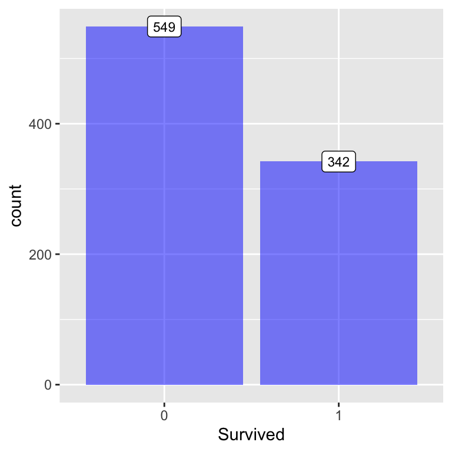

```r
all$Survived <- as.factor(all$Survived)
ggplot(na.omit(all), aes(Survived)) + geom_bar(alpha=0.5, fill='blue') + geom_label(stat = "count", aes(label = ..count.., y = ..count..), size=3)
```

Out of 891 passengers, 549 (62%) died and 342 (38%) survived.

### 4.1.2 Independent Numerical Variables: `Age` and `Fare`

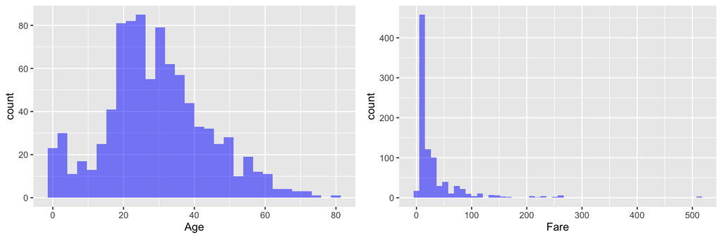

```r
h1 <- ggplot(na.omit(all), aes(Age)) + geom_histogram(data=na.omit(all), bins=30, fill='blue', alpha=0.5)
h2 <- ggplot(na.omit(all), aes(Fare)) + geom_histogram(data=na.omit(all), bins=50, fill='blue', alpha=0.5)
grid.arrange(
  h1, h2,
  nrow=1,
  bottom = textGrob(
    "",
    gp = gpar(fontface=3, fontsize=9),
    hjust=1,
    x=1
  )
)
```

Both distributions are right skewed.

### 4.1.3 Independent Categorical Variables with Low Cardinality: `Pclass`, `SibSp`, `Parch`, `Sex` and `Embarked`

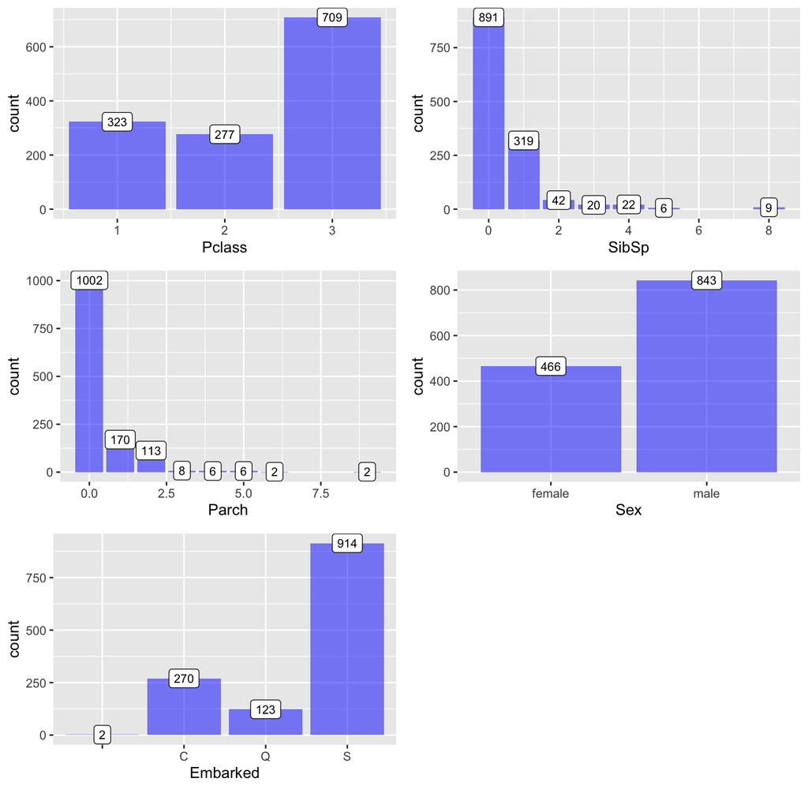

```r
b1 <- ggplot(all, aes(Pclass)) + geom_bar(alpha=0.5,fill='blue') + geom_label(stat = "count", aes(label = ..count.., y = ..count..), size=3)
b2 <- ggplot(all, aes(SibSp)) + geom_bar(alpha=0.5,fill='blue') + geom_label(stat = "count", aes(label = ..count.., y = ..count..), size=3)
b3 <- ggplot(all, aes(Parch)) + geom_bar(alpha=0.5,fill='blue') + geom_label(stat = "count", aes(label = ..count.., y = ..count..), size=3)
b4 <- ggplot(all, aes(Sex)) + geom_bar(alpha=0.5,fill='blue') + geom_label(stat = "count", aes(label = ..count.., y = ..count..), size=3)
b5 <- ggplot(all, aes(Embarked)) + geom_bar(alpha=0.5,fill='blue') + geom_label(stat = "count", aes(label = ..count.., y = ..count..), size=3)
grid.arrange(
  b1, b2, b3, b4, b5,
  nrow=3,
  bottom = textGrob(
    "",
    gp = gpar(fontface=3, fontsize=9),
    hjust=1,
    x=1
  )
)
```

### 4.1.4 Independent Categorical Variables with High Cardinality: `Name`, `Ticket` and `Cabin`

We will check for the uniqueness for the independent categorical variables with high cardinality.

**`Name`**

```r
length(all$Name)
```

```
## [1] 1309
```

```r
length(unique(all$Name))
```

```
## [1] 1307
```

```r
all %>% group_by(Name) %>% dplyr::summarise(n=n()) %>% filter(n>1)
```

```
## # A tibble: 2 x 2
##   Name                     n
##   <chr>                <int>
## 1 Connolly, Miss. Kate     2
## 2 Kelly, Mr. James         2
```

```r
all %>% filter(Name=='Connolly, Miss. Kate' | Name=='Kelly, Mr. James') %>% arrange(Name)
```

```
##   PassengerId Survived Pclass                 Name    Sex  Age SibSp Parch
## 1         290        1      3 Connolly, Miss. Kate female 22.0     0     0
## 2         898     <NA>      3 Connolly, Miss. Kate female 30.0     0     0
## 3         697        0      3     Kelly, Mr. James   male 44.0     0     0
## 4         892     <NA>      3     Kelly, Mr. James   male 34.5     0     0
##   Ticket   Fare Cabin Embarked
## 1 370373 7.7500              Q
## 2 330972 7.6292              Q
## 3 363592 8.0500              S
## 4 330911 7.8292              Q
```

`Name` is unique except for `Connolly, Miss. Kate` and `Kelly, Mr. James`. Each of these names has 2 entries in the data set. Since they are relatively common names and other column values look different enough, we consider them as different passengers.

**`Ticket`**

```r
length(unique(all$Ticket))
```

```
## [1] 929
```

```r
all %>% group_by(Ticket) %>% dplyr::summarise(n=n()) %>% filter(n>1) %>% arrange(desc(n)) %>% head()
```

```
## # A tibble: 6 x 2
##   Ticket       n
##   <chr>    <int>
## 1 CA. 2343    11
## 2 1601         8
## 3 CA 2144      8
## 4 3101295      7
## 5 347077       7
## 6 347082       7
```

`Ticket` values are not unique. Some families/passengers shared the same ticket.

**`Cabin`**

```r
all %>% group_by(Cabin) %>% dplyr::summarise(n=n()) %>% arrange(desc(n)) %>% head()
```

```
## # A tibble: 6 x 2
##   Cabin                 n
##   <chr>             <int>
## 1 ""                 1014
## 2 "C23 C25 C27"         6
## 3 "B57 B59 B63 B66"     5
## 4 "G6"                  5
## 5 "B96 B98"             4
## 6 "C22 C26"             4
```

```r
all %>% filter(Cabin != '') %>% head()
```

```
##   PassengerId Survived Pclass
## 1           2        1      1
## 2           4        1      1
## 3           7        0      1
## 4          11        1      3
## 5          12        1      1
## 6          22        1      2
##                                                  Name    Sex Age SibSp Parch
## 1 Cumings, Mrs. John Bradley (Florence Briggs Thayer) female  38     1     0
## 2        Futrelle, Mrs. Jacques Heath (Lily May Peel) female  35     1     0
## 3                             McCarthy, Mr. Timothy J   male  54     0     0
## 4                     Sandstrom, Miss. Marguerite Rut female   4     1     1
## 5                            Bonnell, Miss. Elizabeth female  58     0     0
## 6                               Beesley, Mr. Lawrence   male  34     0     0
##     Ticket    Fare Cabin Embarked
## 1 PC 17599 71.2833   C85        C
## 2   113803 53.1000  C123        S
## 3    17463 51.8625   E46        S
## 4  PP 9549 16.7000    G6        S
## 5   113783 26.5500  C103        S
## 6   248698 13.0000   D56        S
```

There are 1014 entries with missing `Cabin` (i.e. empty string stored in the column).

## 4.2 Correlations

### 4.2.1 Dependent Variable vs. Independent Variables

Analyzing the correlations between the dependent variable and the independent variables tells us which independent variables could be a strong predictor.

#### 4.2.1.1 Dependent Variable (`Survived`) vs. Numerical Independent Variables (`Age`, `Fare`)

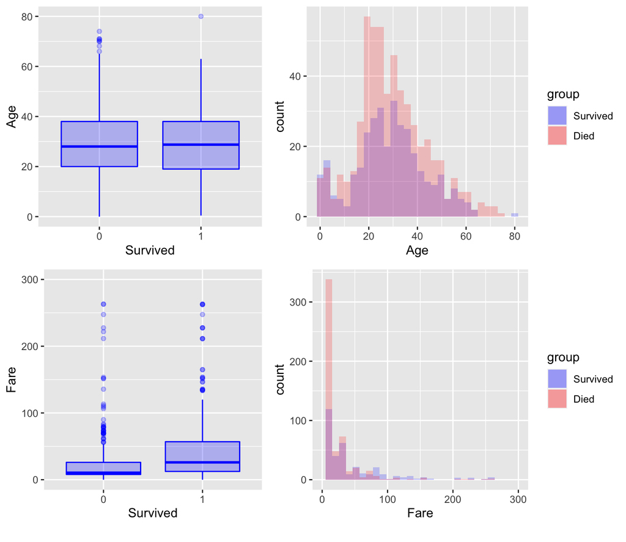

```r
b1 <- ggplot(aes(x=Survived, y=Age), data=na.omit(all)) + geom_boxplot(alpha=0.25, fill='blue', color='blue') +  xlab("Survived")
b2 <- ggplot(aes(x=Survived, y=Fare), data=na.omit(all)) + geom_boxplot(alpha=0.25, fill='blue', color='blue') +  xlab("Survived") + ylim(0, 300)
h1 <- ggplot(na.omit(all), aes(Age)) + geom_histogram(data=subset(na.omit(all), Survived==1), bins=30, aes(fill="blue"), alpha=0.2) + geom_histogram(data=subset(na.omit(all), Survived==0), bins=30, aes(fill="red"), alpha=0.2) + scale_fill_manual(name="group", values=c("blue", "red"), labels=c("Survived", "Died"))
h2 <- ggplot(na.omit(all), aes(Fare)) + geom_histogram(data=subset(na.omit(all), Survived==1), bins=30, aes(fill="blue"), alpha=0.2) + geom_histogram(data=subset(na.omit(all), Survived==0), bins=30, aes(fill="red"), alpha=0.2) + scale_fill_manual(name="group", values=c("blue", "red"), labels=c("Survived", "Died")) + xlim(0, 300)
grid.arrange(
  widths = c(0.75, 1),
  layout_matrix = rbind(c(1, 2), c(3, 4)),
  b1, h1, b2, h2,
  nrow = 2,
  bottom = textGrob(
    "",
    gp = gpar(fontface = 3, fontsize = 9),
    hjust = 1,
    x = 1
  )
)
```

```r
lm_age_survived = lm(Age ~ Survived, data=na.omit(all))
anova(lm_age_survived)
```

```
## Analysis of Variance Table
##
## Response: Age
##            Df Sum Sq Mean Sq F value Pr(>F)
## Survived    1     95  95.318  0.4501 0.5024
## Residuals 889 188253 211.758
```

```r
lm_fare_survived = lm(Fare ~ Survived, data=na.omit(all))
anova(lm_fare_survived)
```

```
## Analysis of Variance Table
##
## Response: Fare
##            Df  Sum Sq Mean Sq F value   Pr(>F)
## Survived    1  145509  145509  63.031 6.12e-15 ***
## Residuals 889 2052290    2309
## ---
## Signif. codes:  0 '***' 0.001 '**' 0.01 '*' 0.05 '.' 0.1 ' ' 1
```

#### 4.2.1.2 Dependent Variable (`Survived`) vs. Categorical Independent Variables (`Pclass`, `Sex`, `SibSp`, `Parch`, `Embarked`)

We first convert the following three variables into factor columns: `Pclass`, `SibSp` and `Parch`.

```r
all$Pclass <- as.factor(all$Pclass)
all$Ticket <- as.factor(all$Ticket)
all$Sex <- as.factor(all$Sex)
all$SibSp <- as.factor(all$SibSp)
all$Parch <- as.factor(all$Parch)
all$Embarked <- as.factor(all$Embarked)
```

We run pairwise **chi-square tests** for all combinations of the variables (`Survived`) and (`Pclass`, `Sex`, `SibSp`, `Parch`, `Embarked`) to evaluate the strength of correlation.

```r
# Run chi-square test for all  of categorical variables
library(plyr)
chi_df <- na.omit(all) %>% dplyr::select(Survived, Pclass, Sex, SibSp, Parch, Embarked)
chi_df <- droplevels(chi_df)
combos <- combn(ncol(chi_df), 2)
corelations <- adply(combos, 2, function(x) {
  column_one <- names(chi_df)[x[1]]
  column_two <- names(chi_df)[x[2]]
  mydata <- data.frame(chi_df[, x[1]], chi_df[, x[2]])
  mytab <- table(mydata)
  chi_test <- chisq.test(mytab)
  out <- data.frame('Column.A' = column_one,
                    'Column.B' = column_two,
                    'p.value' = chi_test$p.value)
  return(out)
})

# Correlation between (`Survived`) and (`Pclass`, `Sex`, `SibSp`, `Parch`, `Embarked`)
corelations %>% filter(Column.A == 'Survived') %>% arrange(p.value)
```

```
##   X1 Column.A Column.B      p.value
## 1  2 Survived      Sex 1.197357e-58
## 2  1 Survived   Pclass 4.549252e-23
## 3  3 Survived    SibSp 1.558581e-06
## 4  5 Survived Embarked 1.618719e-06
## 5  4 Survived    Parch 9.703526e-05
```

**Chi-square tests** of independence show strong dependencies between `Survived` and variables (`Sex`, `Pclass`, `SibSp`, `Embarked`, `Parch`).

**Mosaic Plots**

A mosaic plot is a graphical display of the cell frequencies of a contingency table in which the area of boxes of the plot are proportional to the cell frequencies of the contingency table. The colors represent the level of the residual for that cell / combination of levels. More specifically, **blue means there are more observations in that cell than would be expected under the null model (independent). Red means there are fewer observations than would have been expected.**

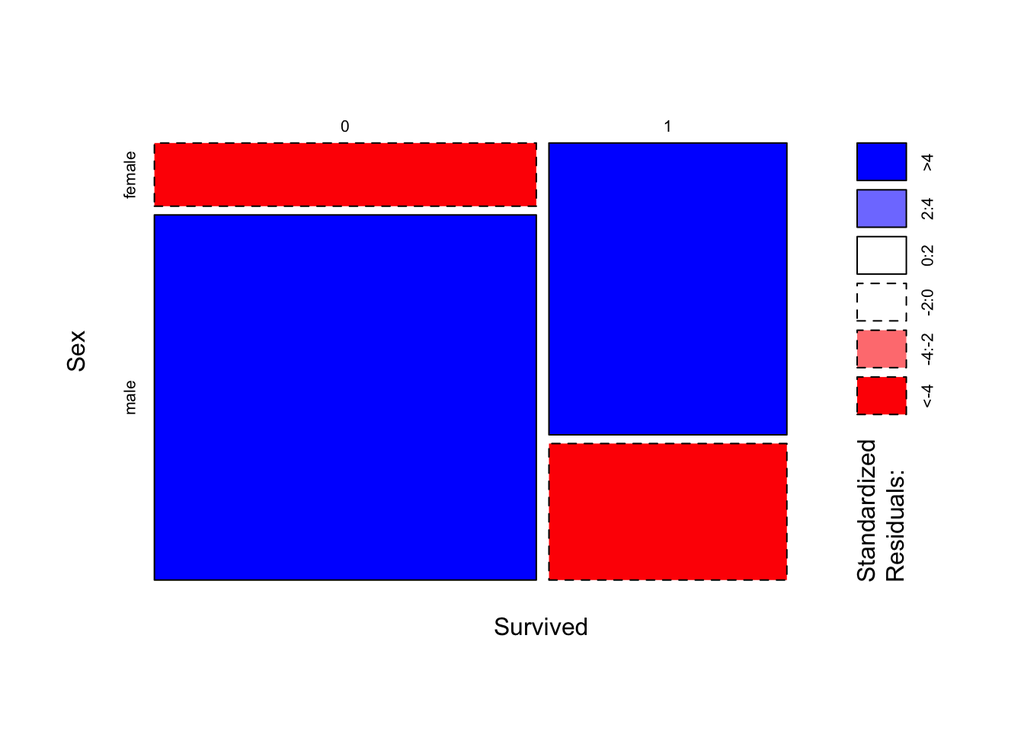

```r
# (Survived, Sex)
mosaicplot(~ na.omit(all)$Survived+train$Sex, data=train, shade=TRUE, legend=TRUE, xlab='Survived', ylab='Sex', main='')
```

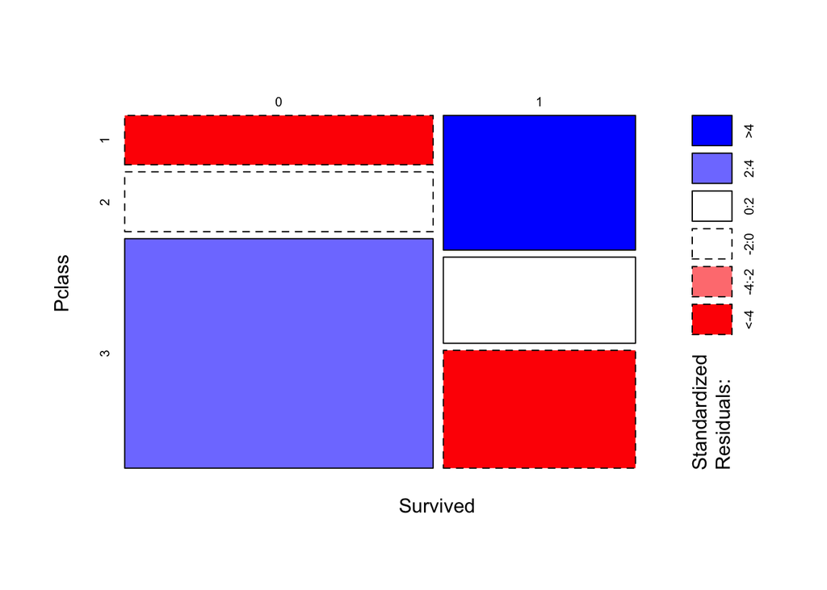

```r
# (Survived, Pclass)
mosaicplot(~ na.omit(all)$Survived+train$Pclass, data=train, shade=TRUE, legend=TRUE, xlab='Survived', ylab='Pclass', main='')
```

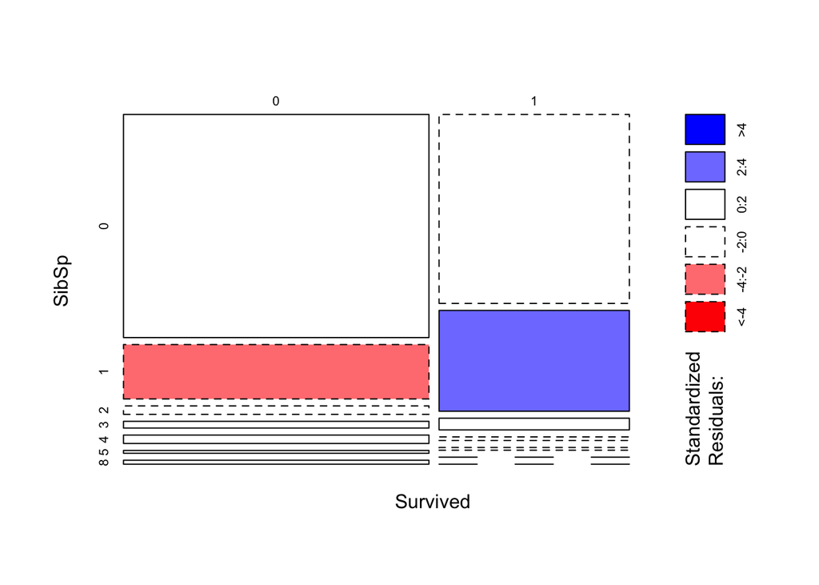

```r
# (Survived, SibSp)
mosaicplot(~ na.omit(all)$Survived+train$SibSp, data=train, shade=TRUE, legend=TRUE, xlab='Survived', ylab='SibSp', main='')
```

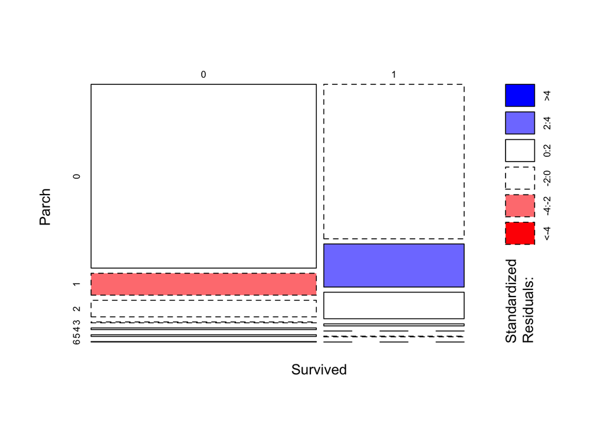

```r
# (Survived, Parch)
mosaicplot(~ na.omit(all)$Survived+train$Parch, data=train, shade=TRUE, legend=TRUE, xlab='Survived', ylab='Parch', main='')
```

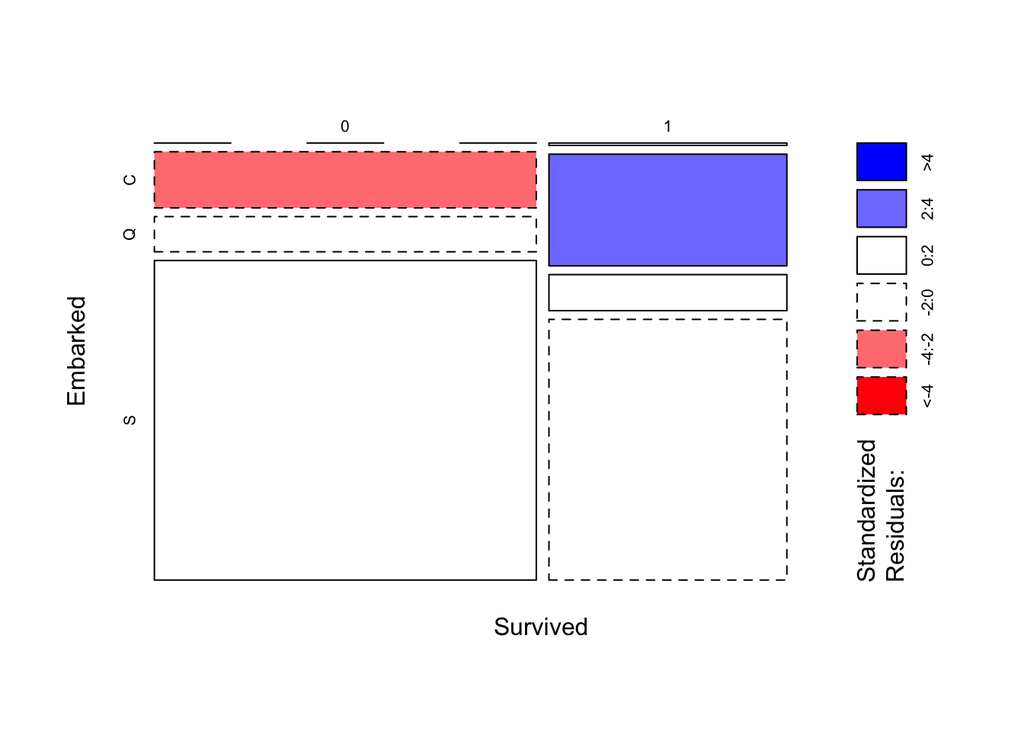

```r
# (Survived, Embarked)
mosaicplot(~ na.omit(all)$Survived+train$Embarked, data=train, shade=TRUE, legend=TRUE, xlab='Survived', ylab='Embarked', main='')
```

### 4.2.2 Independent Variables vs Independent Variables

Studying the correlations between two independent variables tells us about the **multi-collinearity (information redundancy)** of those variables.

#### 4.2.2.1 Independent Numerical Variables vs Independent Numerical Variables: (`Age`, `Fare`)

We look into the correlations between the two numerical variables `Fare` and `Age`. For this, we perform a linear regression and evaluate the goodness of fit (R squared). If R squared is large, then there is a linear relation between the two variable and vice versa if it’s small.

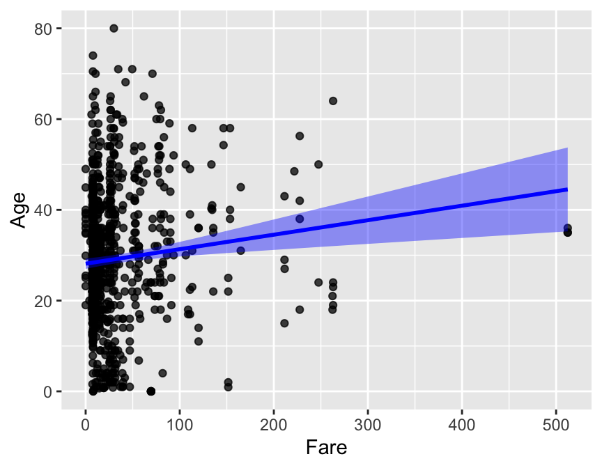

```r
ggplot(na.omit(all), aes(x=Fare, y=Age)) + geom_point(alpha=0.75) + geom_smooth(method=lm, fill="blue", color="blue")
```

```r
lm_age_fare = lm(Age ~ Fare, data=na.omit(all))
summary(lm_age_fare)$r.squared
```

```
## [1] 0.01190687
```

The R squared 0.01190687 suggests a weak to non-existing correlation between the two variables.

#### 4.2.2.2 Independent Categorical Variables vs Independent Categorical Variables: (`Sex`, `Parch`, `SibSp`, `Embarked`, `Pclass`)

```r
# Run chi-square test for all  of categorical variables
library(plyr)
chi_df <- na.omit(all) %>% dplyr::select(Sex, Pclass, SibSp, Parch, Embarked)
chi_df <- droplevels(chi_df)
combos <- combn(ncol(chi_df), 2)
corelations <- adply(combos, 2, function(x) {
  column_one <- names(chi_df)[x[1]]
  column_two <- names(chi_df)[x[2]]
  mydata <- data.frame(chi_df[, x[1]], chi_df[, x[2]])
  mytab <- table(mydata)
  chi_test <- chisq.test(mytab)
  out <- data.frame('Column.A' = column_one,
                    'Column.B' = column_two,
                    'p.value' = chi_test$p.value)
  return(out)
})

# Correlation between `Sex`, `Pclass`, `SibSp`, `Parch`, `Embarked`
corelations %>% arrange(p.value)
```

```
##    X1 Column.A Column.B      p.value
## 1   8    SibSp    Parch 1.790230e-51
## 2   7   Pclass Embarked 1.519464e-25
## 3   3      Sex    Parch 3.816058e-11
## 4   2      Sex    SibSp 8.310305e-08
## 5   5   Pclass    SibSp 9.852350e-07
## 6   1      Sex   Pclass 2.063886e-04
## 7   4      Sex Embarked 7.021496e-04
## 8   9    SibSp Embarked 6.206639e-02
## 9   6   Pclass    Parch 3.785386e-01
## 10 10    Parch Embarked 4.937442e-01
```

**Chi-square tests** of independence show strong dependencies between (`Sex`,`Parch`), (`Sex`,`SibSp`), (`Sex`,`Embarked`), (`Sex`, `Pclass`), (`Pclass`,`Embarked`), (`Pclass`,`SibSp`) and (`SibSp`,`Parch`).

#### 4.2.2.3 Independent Numerical Variables (`Age`, `Fare`) vs Independent Categorical Variables (`Pclass`, `Sex`, `SibSp`, `Parch`, `Embarked`)

**`Age`**

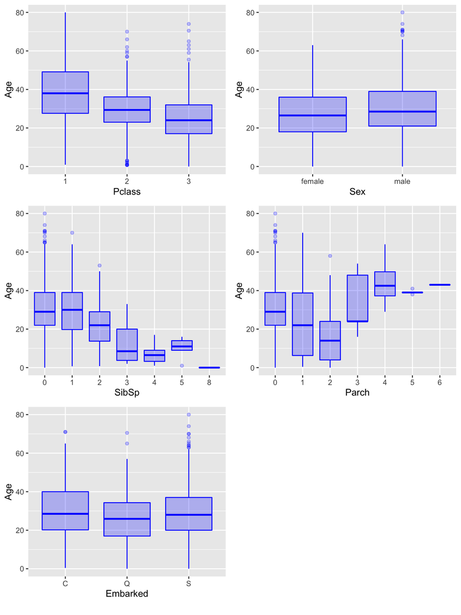

```r
b1 <- ggplot(aes(x=as.factor(Pclass), y=Age), data=na.omit(all)) + geom_boxplot(alpha=0.25, fill='blue', color='blue') + xlab("Pclass")
b2 <- ggplot(aes(x=Sex, y=Age), data=na.omit(all)) + geom_boxplot(alpha=0.25, fill='blue', color='blue') + xlab("Sex")
b3 <- ggplot(aes(x=as.factor(SibSp), y=Age), data=na.omit(all)) + geom_boxplot(alpha=0.25, fill='blue', color='blue') + xlab("SibSp")
b4 <- ggplot(aes(x=as.factor(Parch), y=Age), data=na.omit(all)) + geom_boxplot(alpha=0.25, fill='blue', color='blue') + xlab("Parch")
b5 <- ggplot(aes(x=as.factor(Embarked), y=Age), data=na.omit(all)) + geom_boxplot(data=subset(na.omit(all), Embarked!=''), alpha=0.25, fill='blue', color='blue') + xlab("Embarked")
grid.arrange(
  b1, b2, b3, b4, b5,
  nrow = 3,
  bottom = textGrob(
    "",
    gp = gpar(fontface = 3, fontsize = 9),
    hjust = 1,
    x = 1
  )
)
```

The median `Age` of the passengers increases as the level of class increases. The median of the male passenger age is higher than the female’s.

**`Fare`**

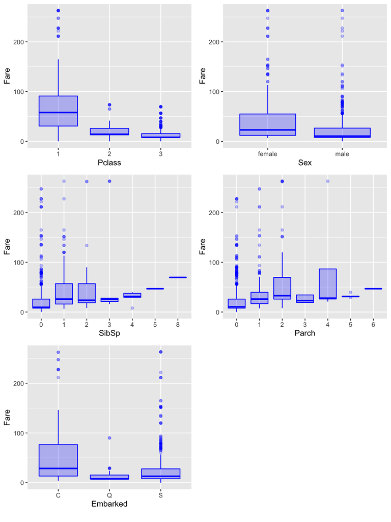

```r
# Exclude Fare > 500
b1 <- ggplot(aes(x=as.factor(Pclass), y=Fare), data=na.omit(all)) + geom_boxplot(data=subset(na.omit(all), Fare<500), alpha=0.25, fill='blue', color='blue') +  xlab("Pclass")
b2 <- ggplot(aes(x=Sex, y=Fare), data=na.omit(all)) + geom_boxplot(data=subset(na.omit(all), Fare<500), alpha=0.25, fill='blue', color='blue') +  xlab("Sex")
b3 <- ggplot(aes(x=as.factor(SibSp), y=Fare), data=na.omit(all)) + geom_boxplot(data=subset(na.omit(all), Fare<500), alpha=0.25, fill='blue', color='blue') +  xlab("SibSp")
b4 <- ggplot(aes(x=as.factor(Parch), y=Fare), data=na.omit(all)) + geom_boxplot(data=subset(na.omit(all), Fare<500), alpha=0.25, fill='blue', color='blue') +  xlab("Parch")
b5 <- ggplot(aes(x=as.factor(Embarked), y=Fare), data=na.omit(all)) + geom_boxplot(data=subset(na.omit(all), Embarked!='' & Fare<500), alpha=0.25, fill='blue', color='blue') +  xlab("Embarked")
grid.arrange(
  b1, b2, b3, b4, b5,
  nrow = 3,
  bottom = textGrob(
    "",
    gp = gpar(fontface = 3, fontsize = 9),
    hjust = 1,
    x = 1
  )
)
```

First class passengers paid the highest fare. Female passengers paid higher price at median.

# 5 Preprocessing / Feature Engineering

## 5.1 Transformation

```r
str(all)
```

```
## 'data.frame':    1309 obs. of  12 variables:
##  $ PassengerId: int  1 2 3 4 5 6 7 8 9 10 ...
##  $ Survived   : Factor w/ 2 levels "0","1": 1 2 2 2 1 1 1 1 2 2 ...
##  $ Pclass     : Factor w/ 3 levels "1","2","3": 3 1 3 1 3 3 1 3 3 2 ...
##  $ Name       : chr  "Braund, Mr. Owen Harris" "Cumings, Mrs. John Bradley (Florence Briggs Thayer)" "Heikkinen, Miss. Laina" "Futrelle, Mrs. Jacques Heath (Lily May Peel)" ...
##  $ Sex        : Factor w/ 2 levels "female","male": 2 1 1 1 2 2 2 2 1 1 ...
##  $ Age        : num  22 38 26 35 35 ...
##  $ SibSp      : Factor w/ 7 levels "0","1","2","3",..: 2 2 1 2 1 1 1 4 1 2 ...
##  $ Parch      : Factor w/ 8 levels "0","1","2","3",..: 1 1 1 1 1 1 1 2 3 1 ...
##  $ Ticket     : Factor w/ 929 levels "110152","110413",..: 721 817 915 66 650 374 110 542 478 175 ...
##  $ Fare       : num  7.25 71.28 7.92 53.1 8.05 ...
##  $ Cabin      : chr  "" "C85" "" "C123" ...
##  $ Embarked   : Factor w/ 4 levels "","C","Q","S": 4 2 4 4 4 3 4 4 4 2 ...
```

**`Name`**

We split `Name` into `FirstName`, `LastName` and `Title`: e.g. “Braund, Mr. Owen Harris” -> “Owen Harris”, “Braund”, “Mr.”.

```r
library(stringr)
all$LastName <- str_split_fixed(all$Name, ",", 2)[,1]
tmp <- str_split_fixed(all$Name, ",", 2)[,2]
all$Title <- trimws(str_split_fixed(tmp, "\\.", 2)[,1])
all$FirstName <- str_split_fixed(tmp, "\\.", 2)[,2]
```

We assigned value `Special` to all `Title` values that are not in (`Mr`, `Miss`, `Mrs`). We will later drop the columns `Name`, `FirstName` and `LastName`.

```r
all %>% group_by(Title) %>% dplyr::summarise(n=n()) %>% arrange(desc(n))
```

```
## # A tibble: 18 x 2
##    Title            n
##    <chr>        <int>
##  1 Mr             757
##  2 Miss           260
##  3 Mrs            197
##  4 Master          61
##  5 Dr               8
##  6 Rev              8
##  7 Col              4
##  8 Major            2
##  9 Mlle             2
## 10 Ms               2
## 11 Capt             1
## 12 Don              1
## 13 Dona             1
## 14 Jonkheer         1
## 15 Lady             1
## 16 Mme              1
## 17 Sir              1
## 18 the Countess     1
```

```r
all$Title[!(all$Title %in% c('Mr', 'Miss', 'Mrs'))] <- 'Special'
all$Title <- as.factor(all$Title)
```

**`Ticket`**

We extract only alphabet characters from this column: e.g. “PC 17599” -> “PC”

```r
all$TicketLetters <- sub("^([[:alpha:]]*).*", "\\1", all$Ticket)
all$TicketLetters[all$TicketLetters == ''] <- 'None'
all$TicketLetters[(all$TicketLetters %in% c('LINE', 'PP', 'AQ', 'P', 'WE', 'Fa', 'LP', 'SCO', 'SO', 'SW'))] <- 'Others'
all %>% dplyr::group_by(TicketLetters) %>% dplyr::summarise(n=n()) %>% arrange(desc(n))
```

```
## # A tibble: 12 x 2
##    TicketLetters     n
##    <chr>         <int>
##  1 None            957
##  2 PC               92
##  3 C                55
##  4 A                40
##  5 SOTON            27
##  6 SC               25
##  7 CA               22
##  8 STON             22
##  9 S                21
## 10 Others           19
## 11 W                17
## 12 F                12
```

```r
all$TicketLetters <- as.factor(all$TicketLetters)
```

**`Cabin`**

We create a new attribute `CabinClass` with the first alphabet character stored in this column: “C85” -> “C”.

```r
all$CabinClass <- sub("^([[:alpha:]]*).*", "\\1", all$Cabin)
all$CabinClass[all$CabinClass == ''] <- 'None'
all$CabinClass[(all$CabinClass %in% c('T','G'))] <- 'None'
all %>% dplyr::group_by(CabinClass) %>% dplyr::summarise(n=n()) %>% arrange(desc(n))
```

```
## # A tibble: 7 x 2
##   CabinClass     n
##   <chr>      <int>
## 1 None        1020
## 2 C             94
## 3 B             65
## 4 D             46
## 5 E             41
## 6 A             22
## 7 F             21
```

```r
all$CabinClass <- as.factor(all$CabinClass)
all <- all %>% dplyr::select(-Cabin)
```

**`FamSizeBinned`**

We will bin the familiy size into three classes: i.e. ‘Solo’, ‘Small’ and ‘Large’.

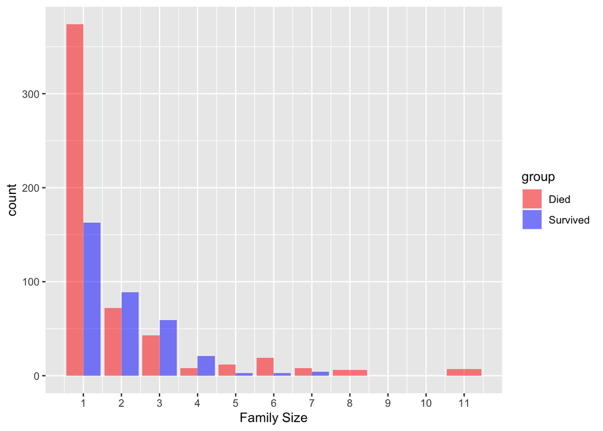

```r
all <- all %>% mutate(FamSize = as.numeric(as.character(SibSp)) + as.numeric(as.character(Parch)) + 1)
famsize_df <- all %>% filter(!is.na(Survived))
ggplot(famsize_df, aes(x=FamSize, fill=as.factor(Survived))) + geom_bar(stat='count', position='dodge', alpha=0.5) + scale_x_continuous(breaks=c(1:11)) + labs(x='Family Size') + theme_grey() + scale_fill_manual(name="group", values=c("red", "blue"),labels=c("Died", "Survived"))
```

```r
all$FamSizeBinned[all$FamSize == 1] <- 'Solo'
all$FamSizeBinned[1 < all$FamSize & all$FamSize <= 4] <- 'Small'
all$FamSizeBinned[4 < all$FamSize] <- 'Large'
all$FamSizeBinned <- as.factor(all$FamSizeBinned)
```

**Drop some variables**

```r
all <- all %>% dplyr::select(-Name, -FirstName, -LastName, -FamSize, -SibSp, -Parch, -Ticket)
str(all)
```

```
## 'data.frame':    1309 obs. of  11 variables:
##  $ PassengerId  : int  1 2 3 4 5 6 7 8 9 10 ...
##  $ Survived     : Factor w/ 2 levels "0","1": 1 2 2 2 1 1 1 1 2 2 ...
##  $ Pclass       : Factor w/ 3 levels "1","2","3": 3 1 3 1 3 3 1 3 3 2 ...
##  $ Sex          : Factor w/ 2 levels "female","male": 2 1 1 1 2 2 2 2 1 1 ...
##  $ Age          : num  22 38 26 35 35 ...
##  $ Fare         : num  7.25 71.28 7.92 53.1 8.05 ...
##  $ Embarked     : Factor w/ 4 levels "","C","Q","S": 4 2 4 4 4 3 4 4 4 2 ...
##  $ Title        : Factor w/ 4 levels "Miss","Mr","Mrs",..: 2 3 1 3 2 2 2 4 3 3 ...
##  $ TicketLetters: Factor w/ 12 levels "A","C","CA","F",..: 1 7 11 5 5 5 5 5 5 5 ...
##  $ CabinClass   : Factor w/ 7 levels "A","B","C","D",..: 7 3 7 3 7 7 5 7 7 7 ...
##  $ FamSizeBinned: Factor w/ 3 levels "Large","Small",..: 2 2 3 2 3 3 3 1 2 2 ...
```

## 5.2 Normalization

We normalize (scale and center) the two numerical variables: `Age` and `Fare`.

```r
library(caret)
preProc <- preProcess(all[,-(1:2)], method=c("center", "scale"))
preProc
```

```
## Created from 1309 samples and 9 variables
##
## Pre-processing:
##   - centered (2)
##   - ignored (7)
##   - scaled (2)
```

```r
all <- predict(preProc, all)
```

## 5.3 Encoding

We take one-hot encoding of the factor variables.

```r
str(all)
```

```
## 'data.frame':    1309 obs. of  11 variables:
##  $ PassengerId  : int  1 2 3 4 5 6 7 8 9 10 ...
##  $ Survived     : Factor w/ 2 levels "0","1": 1 2 2 2 1 1 1 1 2 2 ...
##  $ Pclass       : Factor w/ 3 levels "1","2","3": 3 1 3 1 3 3 1 3 3 2 ...
##  $ Sex          : Factor w/ 2 levels "female","male": 2 1 1 1 2 2 2 2 1 1 ...
##  $ Age          : num  -0.516 0.604 -0.236 0.394 0.394 ...
##  $ Fare         : num  -0.503 0.735 -0.49 0.383 -0.488 ...
##  $ Embarked     : Factor w/ 4 levels "","C","Q","S": 4 2 4 4 4 3 4 4 4 2 ...
##  $ Title        : Factor w/ 4 levels "Miss","Mr","Mrs",..: 2 3 1 3 2 2 2 4 3 3 ...
##  $ TicketLetters: Factor w/ 12 levels "A","C","CA","F",..: 1 7 11 5 5 5 5 5 5 5 ...
##  $ CabinClass   : Factor w/ 7 levels "A","B","C","D",..: 7 3 7 3 7 7 5 7 7 7 ...
##  $ FamSizeBinned: Factor w/ 3 levels "Large","Small",..: 2 2 3 2 3 3 3 1 2 2 ...
```

```r
# Drop levels with no entries
all <- droplevels(all)

# One-hot encoding using model.matrix()
#all <- as.data.frame(model.matrix( ~ . -1, all))

# Standarize weird column names
#colnames(all) <- make.names(colnames(all))
```

## 5.4 Cleaning

We drop factor levels with near zero variance.

```r
# Remove variables with zero (near zero) variance
drop_zerovar <- nearZeroVar(all)
colnames(all[, c(drop_zerovar)])
```

```
## character(0)
```

```r
if (length(colnames(all[, c(drop_zerovar)]))!=0) {
  all <- all[, -c(drop_zerovar)]
}
```

Drop variables that are perfectly collinear with other variables.

```r
# Remove perfectly collinear columns
drop_collinear <- c(rownames(alias(lm(PassengerId ~ . , data=all))$Complete))
drop_collinear
```

```r
all <- all %>% dplyr::select(-all_of(drop_collinear))
```

## 5.5 Feature Selection by Importance

We use random forest with 100 trees to quickly evaluate the important features.

```r
# Run a quick random forest with 100 trees to find important features
library(randomForest)
```

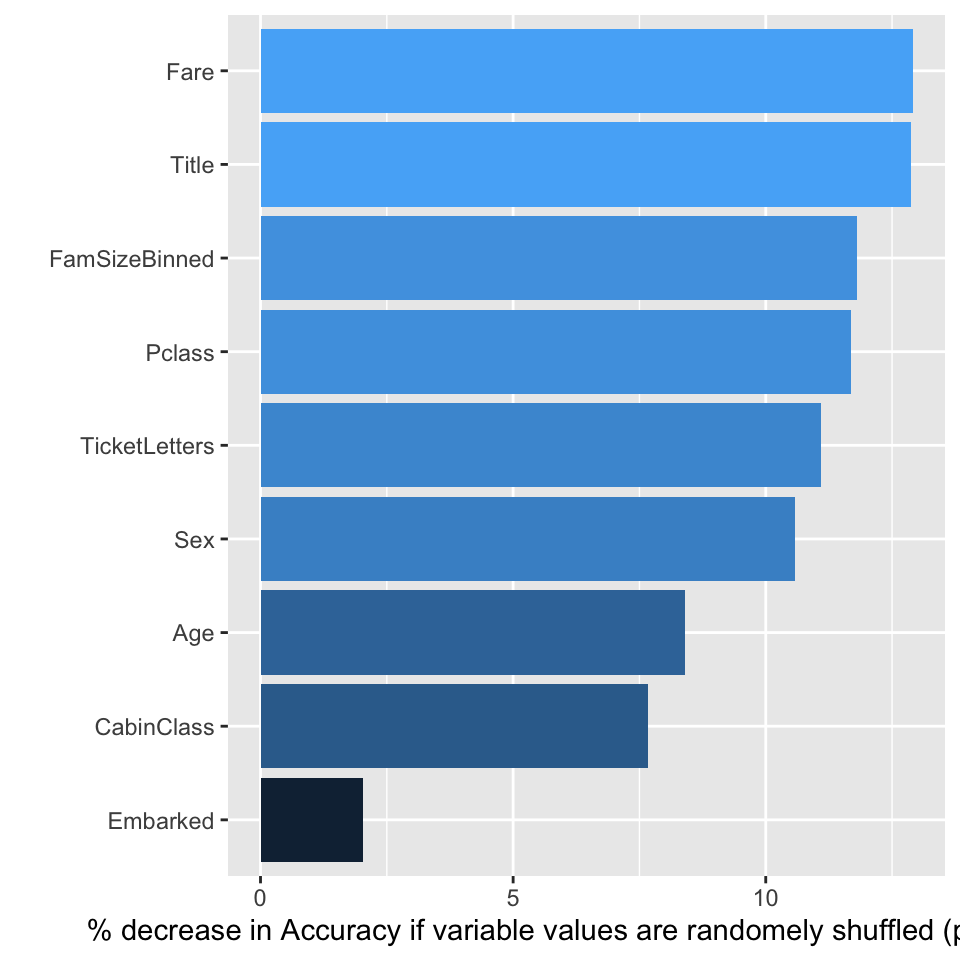

```r
rf_df <- all %>% filter(!is.na(Survived))
set.seed(1)
model_rf <- randomForest(as.factor(Survived) ~ . -PassengerId, data=rf_df, ntree=100, importance=TRUE)
imp_RF <- importance(model_rf)
imp_DF <- data.frame(Variables=row.names(imp_RF), MDA=imp_RF[,1])
imp_DF <- imp_DF[order(imp_DF$MDA, decreasing=TRUE),]
imp_var <- c(imp_DF[,'Variables'])
ggplot(imp_DF, aes(x=reorder(Variables, MDA), y=MDA, fill=MDA)) + geom_bar(stat='identity') + labs(x='', y='% decrease in Accuracy if variable values are randomely shuffled (permuted)') + coord_flip() + theme(legend.position="none")
```

```r
# We drop features with negative importance
important_features <- imp_DF %>% filter(MDA>0) %>% rownames()
important_features
```

```
## [1] "Fare"          "Title"         "FamSizeBinned" "Pclass"
## [5] "TicketLetters" "Sex"           "Age"           "CabinClass"
## [9] "Embarked"
```

```r
all <- all %>% dplyr::select(PassengerId, Survived, all_of(important_features))
```

# 6 Modeling

We re-split the data set `all` to `train` and `test`.

```r
train <- all %>% filter(!is.na(Survived))
test <- all %>% filter(is.na(Survived))
```

## 6.1 Linear Discrimnant Analysis

LDA uses continuous independent variables and a categorical dependent variable. It tries to find a linear hyperplane that maximizes the ratio between the within class variance and the inter class variance. Following are the fundamental assumptions of LDA (from wiki):

1. **multivariate normality**: independent variables are distributed normally for each level of the grouping variable.
2. **homogeneity of variance / covariance (homoscedasticity)**: variances among group variables are the same across levels of predictors. This can be tested with **Box’s M** statistic. **Linear discriminant analysis** are typically used when the covariances are equal and **quadratic discriminant analysis** when covariances are not equal.
3. **multicollinearity**: predictive power can decrease with an increased correlation between predictor variables.
4. **independence**: observations are assumed to be randomly sampled, and a participant’s score on one variable is assumed to be independent of scores on that variable for all other participants.

```r
# Linear Discriminant Analysis
library(pROC)
model.lda <- lda(as.factor(Survived) ~ . -PassengerId, data=train)
pred.lda <- predict(model.lda, train)
confusionMatrix(pred.lda$class, as.factor(train$Survived))
```

```
## Confusion Matrix and Statistics
##
##           Reference
## Prediction   0   1
##          0 482  85
##          1  67 257
##
##                Accuracy : 0.8294
##                  95% CI : (0.8031, 0.8535)
##     No Information Rate : 0.6162
##     P-Value [Acc > NIR] : <2e-16
##
##                   Kappa : 0.6357
##
##  Mcnemar's Test P-Value : 0.1679
##
##             Sensitivity : 0.8780
##             Specificity : 0.7515
##          Pos Pred Value : 0.8501
##          Neg Pred Value : 0.7932
##              Prevalence : 0.6162
##          Detection Rate : 0.5410
##    Detection Prevalence : 0.6364
##       Balanced Accuracy : 0.8147
##
##        'Positive' Class : 0
##
```

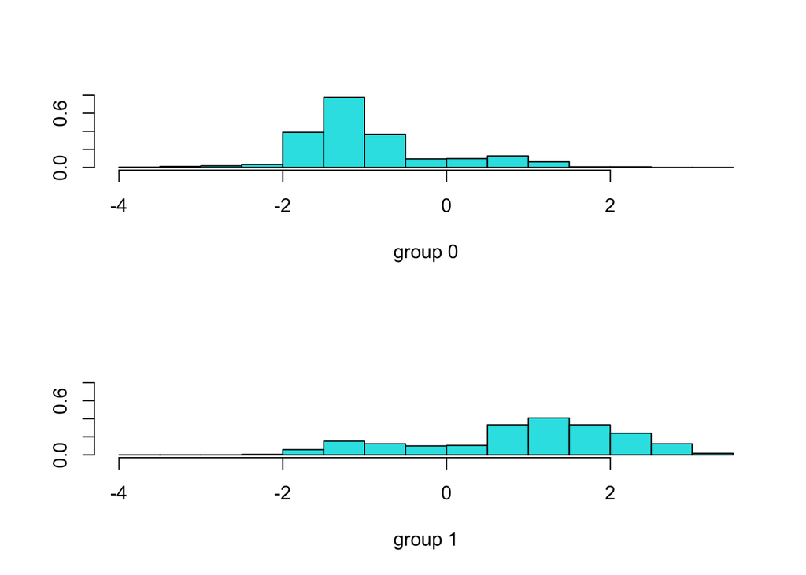

```r
plot(model.lda)
```

```r
roc.lda <- roc(response=train$Survived, predictor=pred.lda$posterior[,1])
```

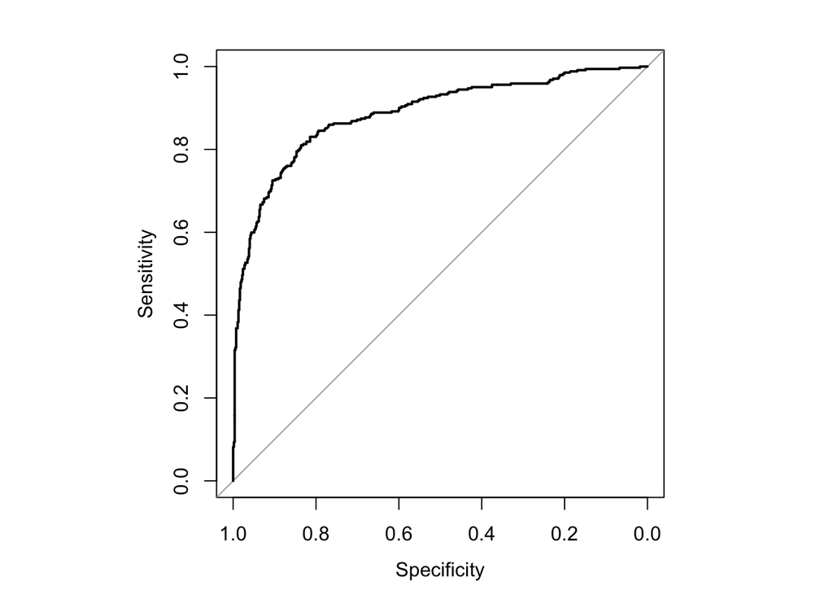

```r
par(pty="s")
plot(roc.lda)
```

```r
auc(roc.lda)
```

```
## Area under the curve: 0.8859
```

```r
test$Survived <- predict(model.lda, test)$class
submission.lda <- test %>% dplyr::select(PassengerId, Survived)
write.csv(submission.lda,"submission_lda.csv", row.names=FALSE) # 0.8859
```

## 6.2 Logistic Regressions

We try two logistic regression models with `caret` and choose the optimal hyperparameter for each models using cross validation.

We start with a **simple logistic regression**.

```r
model.log <- glm(as.factor(Survived) ~ . -PassengerId, data=train, family=binomial)
prob.log <- predict(model.log, train, type="response")
class.log <- rep("0", dim(train)[1])
class.log[prob.log > .5] = "1"
confusionMatrix(as.factor(class.log), as.factor(train$Survived))
```

```
## Confusion Matrix and Statistics
##
##           Reference
## Prediction   0   1
##          0 477  81
##          1  72 261
##
##                Accuracy : 0.8283
##                  95% CI : (0.8019, 0.8525)
##     No Information Rate : 0.6162
##     P-Value [Acc > NIR] : <2e-16
##
##                   Kappa : 0.6352
##
##  Mcnemar's Test P-Value : 0.5178
##
##             Sensitivity : 0.8689
##             Specificity : 0.7632
##          Pos Pred Value : 0.8548
##          Neg Pred Value : 0.7838
##              Prevalence : 0.6162
##          Detection Rate : 0.5354
##    Detection Prevalence : 0.6263
##       Balanced Accuracy : 0.8160
##
##        'Positive' Class : 0
##
```

```r
roc.log <- roc(response=train$Survived, predictor=prob.log)
```

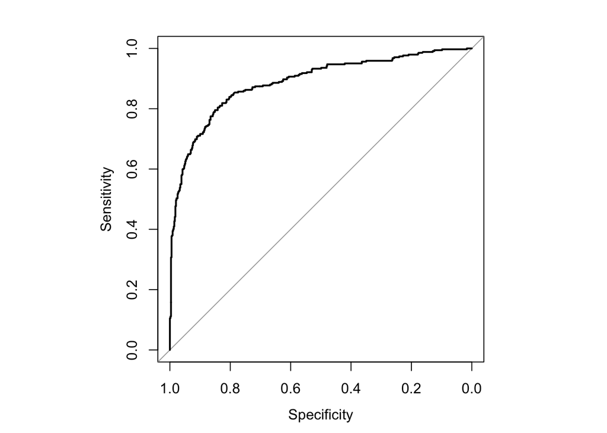

```r
par(pty="s")
plot(roc.log)
```

```r
auc(roc.log)
```

```
## Area under the curve: 0.8876
```

Next, we use **elastic net** logistic regression with penalty both on L1 and L2 norm.

```r
## Set training control for model building
set.seed(1)
ctrl <- trainControl(method="repeatedcv", number=5, repeats=10, summaryFunction=twoClassSummary, classProbs=TRUE, savePredictions=TRUE, search="random")
model.elastic <- train(make.names(as.factor(Survived)) ~ . -PassengerId, data=train, method="glmnet", family="binomial", metric="ROC", trControl=ctrl, Length=10)
model.elastic$bestTune
```

```
##       alpha    lambda
## 1 0.2016819 0.3764085
```

```r
class.elastic <- predict(model.elastic, train, type='raw')
confusionMatrix(as.factor(class.elastic), as.factor(make.names(train$Survived)))
```

```
## Confusion Matrix and Statistics
##
##           Reference
## Prediction  X0  X1
##         X0 519 159
##         X1  30 183
##
##                Accuracy : 0.7879
##                  95% CI : (0.7595, 0.8143)
##     No Information Rate : 0.6162
##     P-Value [Acc > NIR] : < 2.2e-16
##
##                   Kappa : 0.5172
##
##  Mcnemar's Test P-Value : < 2.2e-16
##
##             Sensitivity : 0.9454
##             Specificity : 0.5351
##          Pos Pred Value : 0.7655
##          Neg Pred Value : 0.8592
##              Prevalence : 0.6162
##          Detection Rate : 0.5825
##    Detection Prevalence : 0.7609
##       Balanced Accuracy : 0.7402
##
##        'Positive' Class : X0
##
```

```r
prob.elastic <- predict(model.elastic, train, type='prob')[,1]
roc.elastic <- roc(response=train$Survived, predictor=prob.elastic)
```

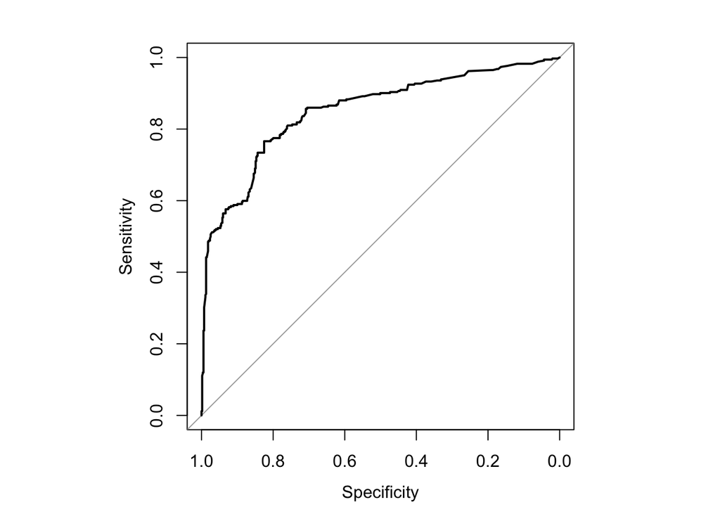

```r
par(pty="s")
plot(roc.elastic)
```

```r
auc(roc.elastic)
```

```
## Area under the curve: 0.8511
```

We make a prediction using the simple logistic regression model as it produces a higher `auc`.

```r
test$Survived <- predict(model.log, test)
test$Survived[test$Survived >  0.5] <- 1
test$Survived[test$Survived <= 0.5] <- 0
submission.log <- test %>% dplyr::select(PassengerId, Survived)
write.csv(submission.log, "submission_log.csv", row.names=FALSE)
```

## 6.3 KNN (Nonparametric Model)

```r
library(class)
trControl <- trainControl(method="cv", number=10)
model.knn <- train(as.factor(Survived) ~ . -PassengerId, data=train, method="knn", tuneGrid=expand.grid(k=1:10), trControl=trControl, metric="Accuracy")
model.knn$bestTune
```

```
##   k
## 5 5
```

```r
class.knn <- predict(model.knn, train, type='raw')
confusionMatrix(as.factor(class.knn), as.factor(train$Survived))
```

```
## Confusion Matrix and Statistics
##
##           Reference
## Prediction   0   1
##          0 500  70
##          1  49 272
##
##                Accuracy : 0.8664
##                  95% CI : (0.8423, 0.8881)
##     No Information Rate : 0.6162
##     P-Value [Acc > NIR] : < 2e-16
##
##                   Kappa : 0.7143
##
##  Mcnemar's Test P-Value : 0.06674
##
##             Sensitivity : 0.9107
##             Specificity : 0.7953
##          Pos Pred Value : 0.8772
##          Neg Pred Value : 0.8474
##              Prevalence : 0.6162
##          Detection Rate : 0.5612
##    Detection Prevalence : 0.6397
##       Balanced Accuracy : 0.8530
##
##        'Positive' Class : 0
##
```

```r
prob.knn <- predict(model.knn, train, type='prob')[,1]
roc.knn <- roc(response=train$Survived, predictor=prob.knn)
```

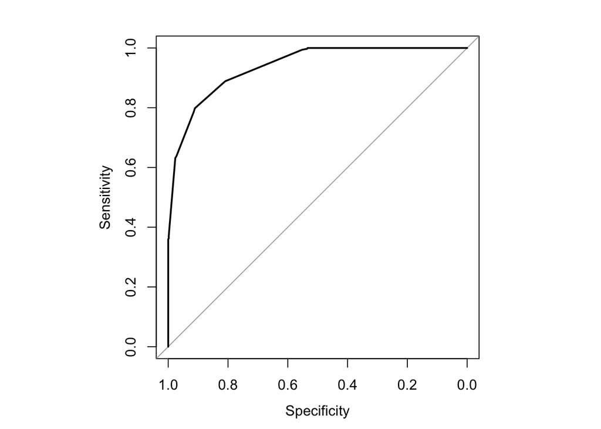

```r
par(pty="s")
plot(roc.knn)
```

```r
auc(roc.knn)
```

```
## Area under the curve: 0.938
```

```r
test$Survived <- predict(model.knn, test, type='raw')
submission.knn <- test %>% dplyr::select(PassengerId, Survived)
write.csv(submission.knn,"submission_knn.csv", row.names=FALSE)
```

## 6.4 Support Vector Machine

We use `caret` to find the optimal parameters (**gamma** and **cost**) for our support vector machine. **Gamma** is the free parameter of the Gaussian radial basis function. A smaller **gamma** means a Gaussian with a larger variance. **Cost** is the parameter for the soft margin cost function and it controls the cost of mis-classification. A smaller **cost** makes the cost of mis-classificaiton low: softer margin.

```r
library(e1071)
set.seed(1)
model.svm <- tune(svm, as.factor(Survived) ~ . -PassengerId, data=train, ranges=list(gamma=2^(-5:0), cost=seq(1.0,1.5,0.1)), kernel="radial", probability=TRUE)
print(model.svm)
```

```
##
## Parameter tuning of 'svm':
##
## - sampling method: 10-fold cross validation
##
## - best parameters:
##   gamma cost
##  0.0625    1
##
## - best performance: 0.1672285
```

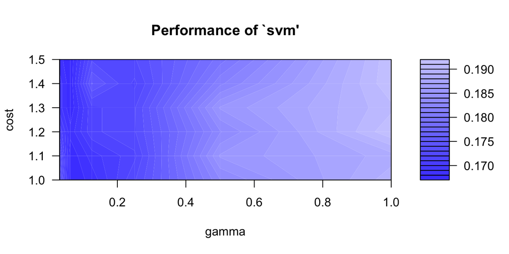

```r
plot(model.svm)
```

```r
class.svm <- predict(model.svm$best.model, train)
pred.svm <- predict(model.svm$best.model, train, probability=TRUE)
prob.svm <- attr(pred.svm, "probabilities")[,1]
confusionMatrix(as.factor(pred.svm), as.factor(train$Survived))
```

```
## Confusion Matrix and Statistics
##
##           Reference
## Prediction   0   1
##          0 492  87
##          1  57 255
##
##                Accuracy : 0.8384
##                  95% CI : (0.8125, 0.862)
##     No Information Rate : 0.6162
##     P-Value [Acc > NIR] : < 2e-16
##
##                   Kappa : 0.6526
##
##  Mcnemar's Test P-Value : 0.01566
##
##             Sensitivity : 0.8962
##             Specificity : 0.7456
##          Pos Pred Value : 0.8497
##          Neg Pred Value : 0.8173
##              Prevalence : 0.6162
##          Detection Rate : 0.5522
##    Detection Prevalence : 0.6498
##       Balanced Accuracy : 0.8209
##
##        'Positive' Class : 0
##
```

```r
roc.svm <- roc(response=train$Survived, predictor=prob.svm)
```

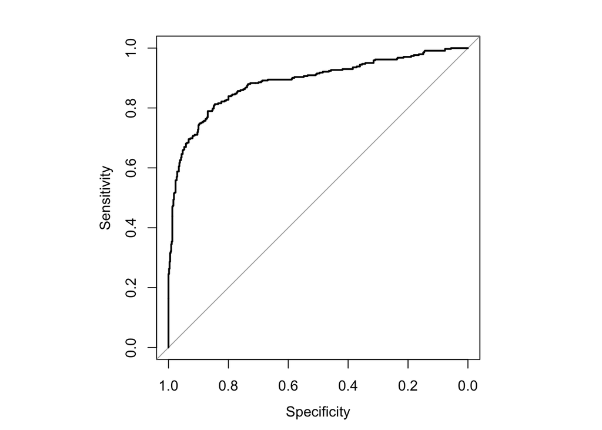

```r
par(pty="s")
plot(roc.svm)
```

```r
auc(roc.svm)
```

```
## Area under the curve: 0.8871
```

```r
test$Survived <- predict(model.svm$best.model, test)
submission.svm <- test %>% dplyr::select(PassengerId, Survived)
write.csv(submission.svm,"submission_svm.csv", row.names=FALSE) # 0.75119
```

## 6.5 Decision Tree

The criteria for a making (or not) a new split in a decision tree is to compare the decrease in the error of the tree with the new split against the **complexity parameter (cp)** times the number of leaves it would yield. If the former is greater, then the split is made.

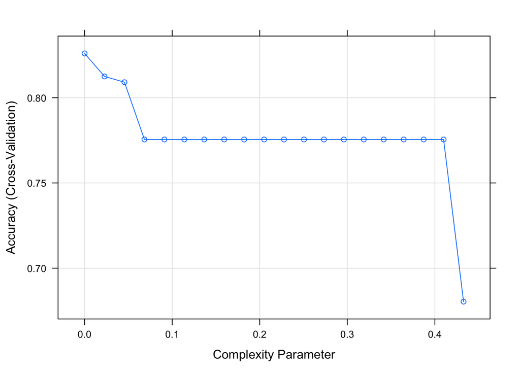

```r
library(rpart)
library(rpart.plot)
set.seed(1)

model.tree <- train(as.factor(Survived) ~ . -PassengerId, data=train, method="rpart", trControl=trainControl("cv", number=10), tuneLength=20)

# Plot model error vs different values of complexity parameter
plot(model.tree)
```

```r
# Print the best tuning parameter cp that minimize the model Accuracy
model.tree$bestTune
```

```
##   cp
## 1  0
```

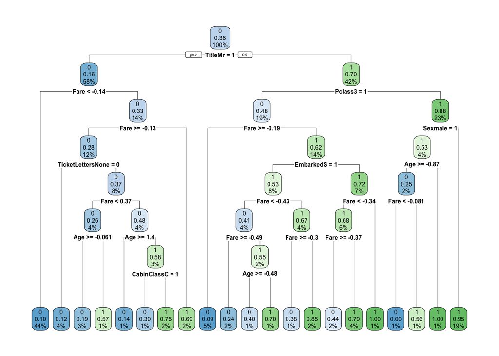

```r
# Plot the final tree model
rpart.plot(model.tree$finalModel)
```

```r
# Decision rules in the model
model.tree$finalModel
```

```
## n= 891
##
## node), split, n, loss, yval, (yprob)
##       * denotes terminal node
##
##   1) root 891 342 0 (0.61616162 0.38383838)
##     2) TitleMr>=0.5 517  81 0 (0.84332689 0.15667311)
##       4) Fare< -0.1354239 390  39 0 (0.90000000 0.10000000) *
##       5) Fare>=-0.1354239 127  42 0 (0.66929134 0.33070866)
##        10) Fare>=-0.1256401 111  31 0 (0.72072072 0.27927928)
##          20) TicketLettersNone< 0.5 40   5 0 (0.87500000 0.12500000) *
##          21) TicketLettersNone>=0.5 71  26 0 (0.63380282 0.36619718)
##            42) Fare< 0.3672147 38  10 0 (0.73684211 0.26315789)
##              84) Age>=-0.06132414 31   6 0 (0.80645161 0.19354839) *
##              85) Age< -0.06132414 7   3 1 (0.42857143 0.57142857) *
##            43) Fare>=0.3672147 33  16 0 (0.51515152 0.48484848)
##              86) Age>=1.408422 7   1 0 (0.85714286 0.14285714) *
##              87) Age< 1.408422 26  11 1 (0.42307692 0.57692308)
##               174) CabinClassC>=0.5 10   3 0 (0.70000000 0.30000000) *
##               175) CabinClassC< 0.5 16   4 1 (0.25000000 0.75000000) *
##        11) Fare< -0.1256401 16   5 1 (0.31250000 0.68750000) *
##     3) TitleMr< 0.5 374 113 1 (0.30213904 0.69786096)
##       6) Pclass3>=0.5 172  83 0 (0.51744186 0.48255814)
##        12) Fare>=-0.1918318 44   4 0 (0.90909091 0.09090909) *
##        13) Fare< -0.1918318 128  49 1 (0.38281250 0.61718750)
##          26) EmbarkedS>=0.5 70  33 1 (0.47142857 0.52857143)
##            52) Fare< -0.4338905 37  15 0 (0.59459459 0.40540541)
##             104) Fare>=-0.4887282 17   4 0 (0.76470588 0.23529412) *
##             105) Fare< -0.4887282 20   9 1 (0.45000000 0.55000000)
##               210) Age>=-0.4812516 10   4 0 (0.60000000 0.40000000) *
##               211) Age< -0.4812516 10   3 1 (0.30000000 0.70000000) *
##            53) Fare>=-0.4338905 33  11 1 (0.33333333 0.66666667)
##             106) Fare>=-0.3029566 13   5 0 (0.61538462 0.38461538) *
##             107) Fare< -0.3029566 20   3 1 (0.15000000 0.85000000) *
##          27) EmbarkedS< 0.5 58  16 1 (0.27586207 0.72413793)
##            54) Fare< -0.3412057 50  16 1 (0.32000000 0.68000000)
##             108) Fare>=-0.3737778 16   7 0 (0.56250000 0.43750000) *
##             109) Fare< -0.3737778 34   7 1 (0.20588235 0.79411765) *
##            55) Fare>=-0.3412057 8   0 1 (0.00000000 1.00000000) *
##       7) Pclass3< 0.5 202  24 1 (0.11881188 0.88118812)
##        14) Sexmale>=0.5 32  15 1 (0.46875000 0.53125000)
##          28) Age>=-0.8661852 20   5 0 (0.75000000 0.25000000)
##            56) Fare< -0.08050603 11   0 0 (1.00000000 0.00000000) *
##            57) Fare>=-0.08050603 9   4 1 (0.44444444 0.55555556) *
##          29) Age< -0.8661852 12   0 1 (0.00000000 1.00000000) *
##        15) Sexmale< 0.5 170   9 1 (0.05294118 0.94705882) *
```

```r
prob.tree <- predict(model.tree, newdata=train, type='prob')[,1]
class.tree <- rep("1", dim(train)[1])
class.tree[prob.tree > .5] = "0"

confusionMatrix(as.factor(class.tree), as.factor(train$Survived))
```

```
## Confusion Matrix and Statistics
##
##           Reference
## Prediction   0   1
##          0 511  78
##          1  38 264
##
##                Accuracy : 0.8698
##                  95% CI : (0.8459, 0.8912)
##     No Information Rate : 0.6162
##     P-Value [Acc > NIR] : < 2.2e-16
##
##                   Kappa : 0.7186
##
##  Mcnemar's Test P-Value : 0.0002934
##
##             Sensitivity : 0.9308
##             Specificity : 0.7719
##          Pos Pred Value : 0.8676
##          Neg Pred Value : 0.8742
##              Prevalence : 0.6162
##          Detection Rate : 0.5735
##    Detection Prevalence : 0.6611
##       Balanced Accuracy : 0.8514
##
##        'Positive' Class : 0
##
```

```r
roc.tree <- roc(response=train$Survived, predictor=prob.tree)
```

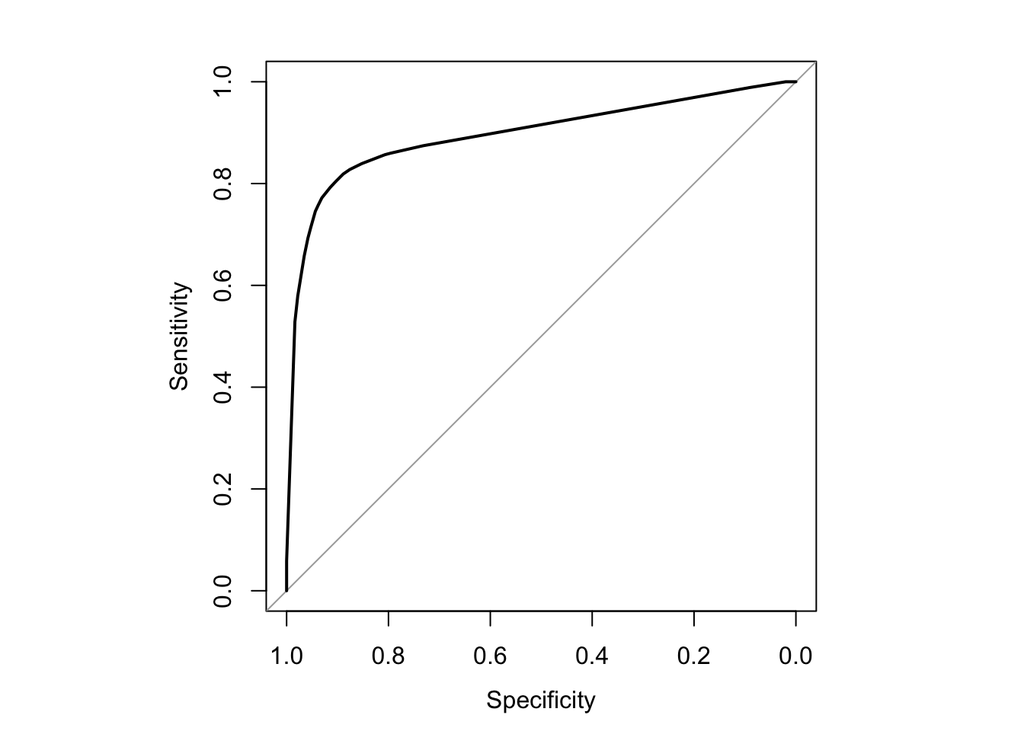

```r
par(pty="s")
plot(roc.tree)
```

```r
auc(roc.tree)
```

```
## Area under the curve: 0.8956
```

```r
test$Survived_ <- predict(model.tree, newdata=test, type='prob')[,1]
test$Survived[test$Survived_ >  0.5] <- 0
test$Survived[test$Survived_ <= 0.5] <- 1
submission.tree <- test %>% dplyr::select(PassengerId, Survived)
write.csv(submission.tree,"submission_tree.csv", row.names=FALSE) # 0.73684
```

## 6.6 Random Forest

Here, we use 5-fold cross validation. **mtry** is the number of variables randomly sampled as candidates at each split.

```r
library(randomForest)
set.seed(5)
control <- trainControl(method="cv", number=5)
model.rf <- train(as.factor(Survived) ~ . -PassengerId, data=train, method="rf", trControl=control, tuneGrid=expand.grid(mtry=2:5))
model.rf$bestTune
```

```
##   mtry
## 3    4
```

```r
prob.rf <- predict(model.rf, train, type='prob')[,1]
class.rf <- rep("1", dim(train)[1])
class.rf[prob.rf > .5] = "0"
confusionMatrix(as.factor(class.rf), as.factor(train$Survived))
```

```
## Confusion Matrix and Statistics
##
##           Reference
## Prediction   0   1
##          0 527  71
##          1  22 271
##
##                Accuracy : 0.8956
##                  95% CI : (0.8737, 0.9149)
##     No Information Rate : 0.6162
##     P-Value [Acc > NIR] : < 2.2e-16
##
##                   Kappa : 0.7732
##
##  Mcnemar's Test P-Value : 6.445e-07
##
##             Sensitivity : 0.9599
##             Specificity : 0.7924
##          Pos Pred Value : 0.8813
##          Neg Pred Value : 0.9249
##              Prevalence : 0.6162
##          Detection Rate : 0.5915
##    Detection Prevalence : 0.6712
##       Balanced Accuracy : 0.8762
##
##        'Positive' Class : 0
##
```

```r
roc.rf <- roc(response=train$Survived, predictor=prob.rf)
```

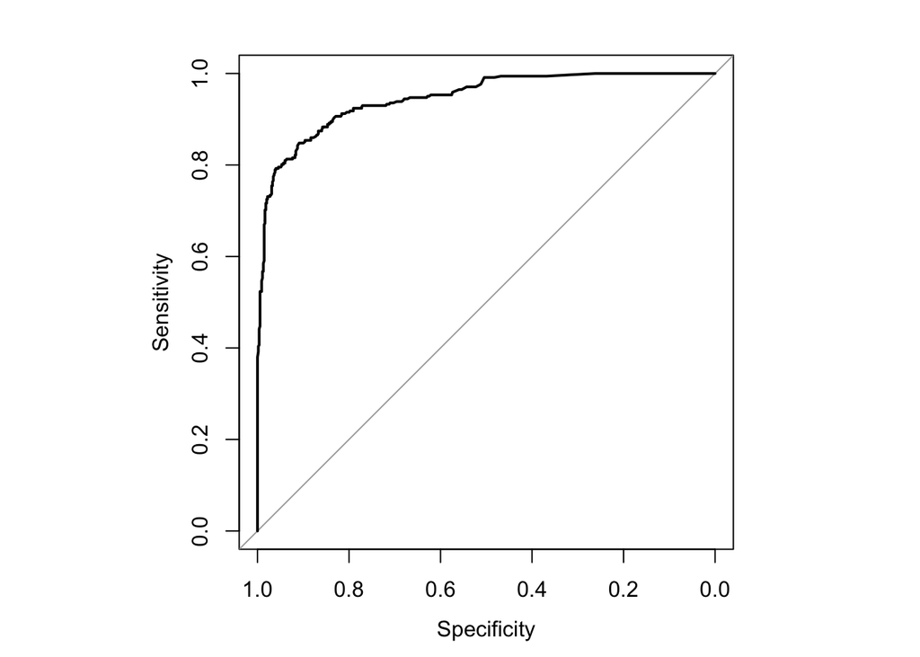

```r
par(pty="s")
plot(roc.rf)
```

```r
auc(roc.rf)
```

```
## Area under the curve: 0.9465
```

```r
test$Survived <- predict(model.rf, test)
submission.rf <- test %>% dplyr::select(PassengerId, Survived)
write.csv(submission.rf,"submission_rf.csv", row.names=FALSE) # 0.77272
```

We extract feature importance.

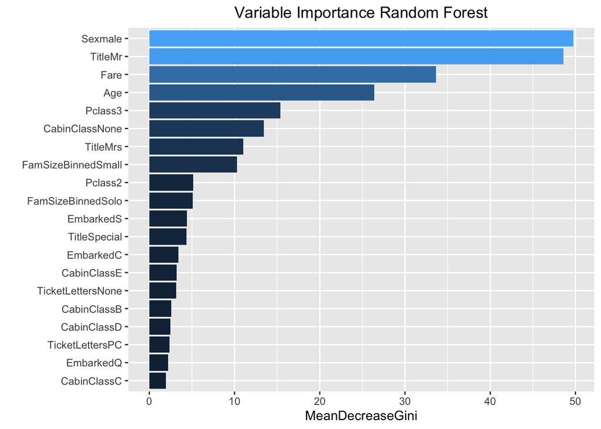

```r
# Extracting variable importance and make graph with ggplot (looks nicer that the standard varImpPlot)
rf_imp <- varImp(model.rf, scale = FALSE)
rf_imp <- rf_imp$importance
rf_gini <- data.frame(Variables=row.names(rf_imp), MeanDecreaseGini=rf_imp$Overall)
ggplot(top_n(rf_gini, 20, MeanDecreaseGini), aes(x=reorder(Variables, MeanDecreaseGini), y=MeanDecreaseGini, fill=MeanDecreaseGini)) +
        geom_bar(stat='identity') + coord_flip() + theme(legend.position="none") + labs(x="") +
        ggtitle('Variable Importance Random Forest') + theme(plot.title = element_text(hjust = 0.5))
```

```r
library(gbm)
set.seed(1)
control <- trainControl(method="cv", number=5)
model.gbm <- train(as.factor(Survived) ~ . -PassengerId, data=train, method='gbm', trControl=control, verbose=FALSE)
prob.gbm <- predict(model.gbm, train, type='prob')[,1]
class.gbm <- rep("1", dim(train)[1])
class.gbm[prob.gbm > .5] = "0"
confusionMatrix(as.factor(class.gbm), as.factor(train$Survived))
```

```
## Confusion Matrix and Statistics
##
##           Reference
## Prediction   0   1
##          0 504  76
##          1  45 266
##
##                Accuracy : 0.8642
##                  95% CI : (0.8399, 0.886)
##     No Information Rate : 0.6162
##     P-Value [Acc > NIR] : < 2.2e-16
##
##                   Kappa : 0.7079
##
##  Mcnemar's Test P-Value : 0.006386
##
##             Sensitivity : 0.9180
##             Specificity : 0.7778
##          Pos Pred Value : 0.8690
##          Neg Pred Value : 0.8553
##              Prevalence : 0.6162
##          Detection Rate : 0.5657
##    Detection Prevalence : 0.6510
##       Balanced Accuracy : 0.8479
##
##        'Positive' Class : 0
##
```

```r
roc.gbm <- roc(response=train$Survived, predictor=prob.gbm)
```

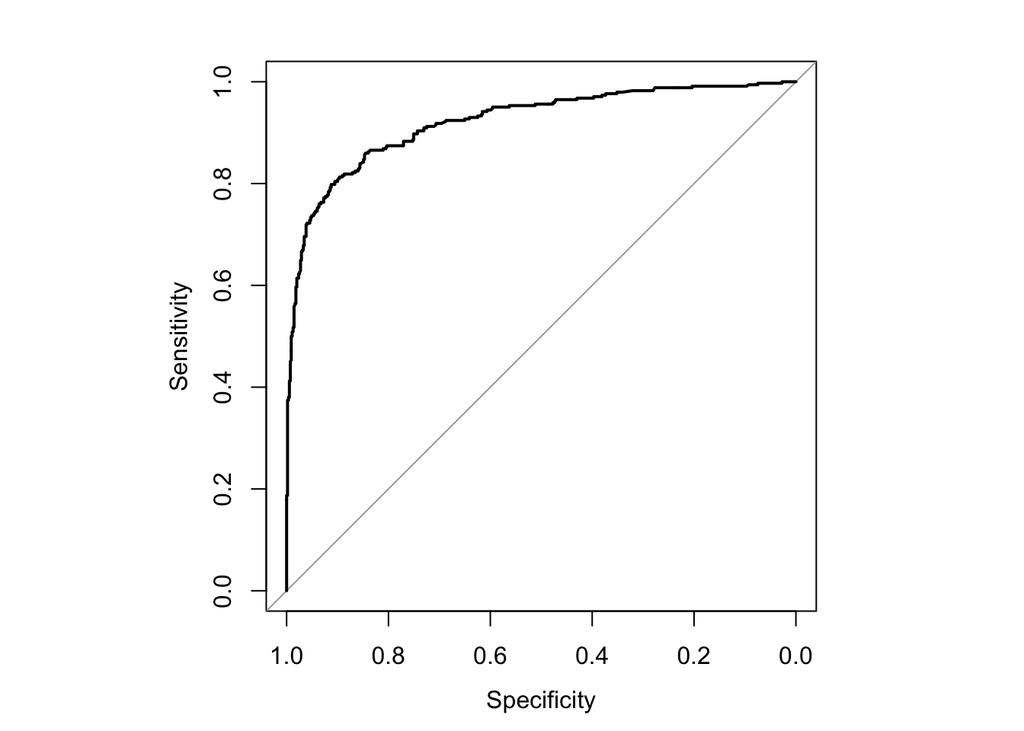

```r
par(pty="s")
plot(roc.gbm)
```

```r
auc(roc.gbm)
```

```
## Area under the curve: 0.9216
```

```r
test$Survived_ <- predict(model.gbm, test, type='prob')[,1]
test$Survived[test$Survived_ >  0.5] <- 0
test$Survived[test$Survived_ <= 0.5] <- 1
submission.gbm <- test %>% dplyr::select(PassengerId, Survived)
write.csv(submission.gbm,"submission_gbm.csv", row.names=FALSE) #
```

## 6.8 Neural Network

We use `caret`’s method `nnet` to run a 5-fold cross validation to find the best number of nodes and weight decay factor.

```r
library(neuralnet)
#http://sebastianderi.com/aexam/hld_MODEL_neural.html

set.seed(1)

# Step 1: SELECT TUNING PARAMETERS
# Set range of tuning parameters (layer size [number of nodes] and weight decay)
tune_grid_neural <- expand.grid(size=c(1:5), decay=c(0, 0.05, 0.1, 0.5, 1))

# Set other constrains to be imposed on network (to keep computation manageable)
max_size_neaural <- max(tune_grid_neural$size)
max_weights_neural <- max_size_neaural*(nrow(train) + 1) + max_size_neaural + 1

# Step 2: SELECT TUNING METHOD
# set up train control object, which specifies training/testing technique
control_neural <- trainControl(method="cv", number=5)

# Step 3: TRAIN MODEL
model.nn <- train(as.factor(Survived) ~ . -PassengerId, data=train, method="nnet", tuneGrid=tune_grid_neural, trControl=control_neural, trace=FALSE)
```

```r
prob.nn <- predict(model.nn, train, type='prob')[,1]
class.nn <- rep("1", dim(train)[1])
class.nn[prob.nn > .5] = "0"
confusionMatrix(as.factor(class.nn), as.factor(train$Survived))
```

```
## Confusion Matrix and Statistics
##
##           Reference
## Prediction   0   1
##          0 511  92
##          1  38 250
##
##                Accuracy : 0.8541
##                  95% CI : (0.8292, 0.8766)
##     No Information Rate : 0.6162
##     P-Value [Acc > NIR] : < 2.2e-16
##
##                   Kappa : 0.6821
##
##  Mcnemar's Test P-Value : 3.345e-06
##
##             Sensitivity : 0.9308
##             Specificity : 0.7310
##          Pos Pred Value : 0.8474
##          Neg Pred Value : 0.8681
##              Prevalence : 0.6162
##          Detection Rate : 0.5735
##    Detection Prevalence : 0.6768
##       Balanced Accuracy : 0.8309
##
##        'Positive' Class : 0
##
```

```r
roc.nn <- roc(response=train$Survived, predictor=prob.nn)
```

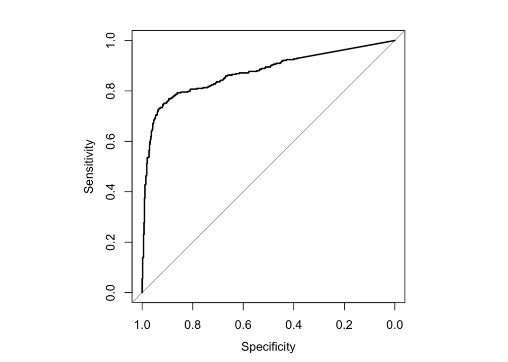

```r
par(pty="s")
plot(roc.nn)
```

```r
auc(roc.nn)
```

```
## Area under the curve: 0.8725
```

```r
test$Survived_ <- predict(model.nn, test, type='prob')[,1]
test$Survived[test$Survived_ >  0.5] <- 0
test$Survived[test$Survived_ <= 0.5] <- 1
submission.nn <- test %>% dplyr::select(PassengerId, Survived)
write.csv(submission.nn,"submission_nn.csv", row.names=FALSE) # 0.77272
```

## 6.9 Combine Models

### 6.9.1 Correlation Between the Model Predictions

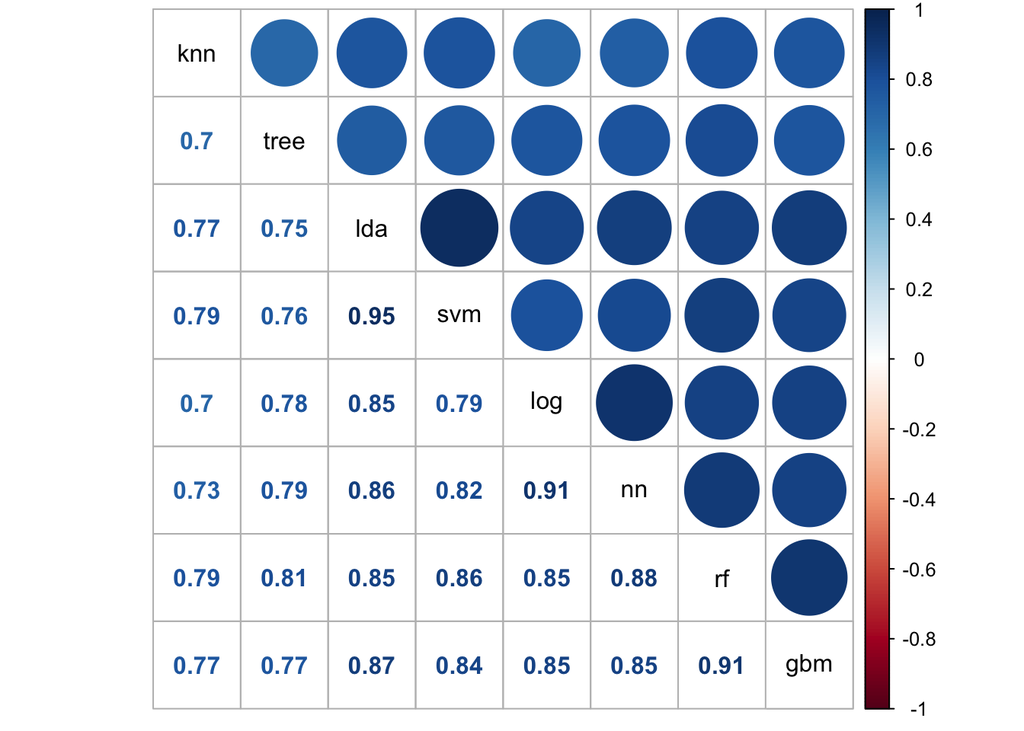

```r
#compose correlations plot
library(corrplot)
results <- as.data.frame(submission.lda[,1:2])
names(results)[1] <- 'PassengerId'
names(results)[2] <- 'lda'
results$log <- submission.log[,2]
results$knn <- submission.knn[,2]
results$svm <- submission.svm[,2]
results$tree <- submission.tree[,2]
results$rf <- submission.rf[,2]
results$gbm <- submission.gbm[,2]
results$nn <- submission.nn[,2]

results$lda <- as.numeric(as.character(results$lda)) # 0.8859
results$log <- as.numeric(as.character(results$log)) # 0.8876
results$knn <- as.numeric(as.character(results$knn)) # 0.938
results$svm <- as.numeric(as.character(results$svm)) # 0.8871
results$tree <- as.numeric(results$tree)             # 0.8956
results$rf <- as.numeric(as.character(results$rf))   # 0.9465
results$gbm <- as.numeric(as.character(results$gbm)) # 0.9216
results$nn <- as.numeric(as.character(results$nn))   # 0.8725

corrplot.mixed(cor(results[, c('lda', 'log', 'knn', 'svm', 'tree', 'rf', 'gbm', 'nn')]), order="hclust", tl.col="black")
```

### 6.9.2 Ensembling 1: Majority Voting Between Multiple Models

```r
results <- results %>% mutate_if(is.numeric, ~replace(., is.na(.), 0))
results <- transform(results, majority=ifelse(svm + rf + gbm > 1, 1, 0))
submission.majority <- results %>% dplyr::select(PassengerId, majority)
names(submission.majority)[2] <- 'Survived'
write.csv(submission.majority,"submission_majority.csv", row.names=FALSE)
```

### 6.9.3 Ensembling 2: Weighted Majority Voting Between Multiple Models

There is another way to take an ensemble of predictions from different models. Here, we will take the svm predictions unless both rf and gbm disagree with the svm prediction.

```r
submission.disagree.svm <- results %>% dplyr::select(PassengerId, svm, rf, gbm)
submission.disagree.svm$Survived <- ifelse(results$svm==results$gbm | results$svm==results$rf, results$svm, results$rf)
submission.disagree.svm <- submission.disagree.svm %>% dplyr::select(PassengerId, Survived)
write.csv(submission.disagree.svm,"submission_disagree_svm.csv", row.names=FALSE)
```

Checkout this excellent blog post about practical ensembling techniques: https://mlwave.com/kaggle-ensembling-guide/